# PracticalML_FinalProject

AR

7/26/2021

# Coursera Practical Machine Learning – Course Project

A. Ridgway 22 JULY 2021

## Assignment

This assignment is based on a study in which participants’ body motions were recorded by accelerometers as weight-lifting exercises were performed: Wearable Computing: Accelerometers’ Data Classification of Body Postures and Movements by: Ugulino, W.; Cardador, D.; Vega, K.; Velloso, E.; Milidiu, R.; Fuks, H. Proceedings of 21st Brazilian Symposium on Artificial Intelligence. Advances in Artificial Intelligence - SBIA 2012. In: Lecture Notes in Computer Science. , pp. 52-61. Curitiba, PR: Springer Berlin / Heidelberg, 2012. ISBN 978-3-642-34458-9. DOI: 10.1007/978-3-642-34459-6_6.

The participants performed exercises using 5 different techniques where technique A being perfect form and techniques B through E incorrect forms. The goal of this assignment was to build a model for predicting the technique in which barbell lifts were performed based on data from accelerometers placed on the belt, forearm, arm, and dumbbell of 6 participants.

## Summary

For this assignment, a model was built and tested using the following steps:

- Basic data exploration of training data
- Data Cleaning and Initial Subsets
- Feature Selection
- Pre-processing Training Data
- Partitioning Training Data: Test and Verify
- Model Fitting
- Model Testing: Predictions with Verify data

```r
# Libraries Used
library(dplyr)
library(stringr)
library(caret)
library(data.table)
library(lubridate)
library(knitr);library(kableExtra)
library(parallel)
library(doParallel)
```

```r
##Functions
# Count NA or blank data (df = datatable containing NAs)
dfNas<-function(df) {
        resultNAs<-sapply(df,function(x) round(100*as.numeric(sum(is.na(x)|str_trim(x,side=c("both"))=="")/nrow(df)),2))
        return(resultNAs)
}
# Create information table of variables (df = datatable to process)
dfInfo<-function(df) {
        NAs<-dfNas(df);dfCols<-colnames(df);dfTypes<-sapply(df,class);
        dfnvals<-round(nrow(df)*(1-NAs/100),0)
        dfResult<-data.frame(cbind(name=dfCols,type=dfTypes,pctNA=NAs,nvals=dfnvals),row.names = NULL)
        dfResult$pctNA<-as.numeric(dfResult$pctNA);dfResult$nvals<-as.numeric(dfResult$nvals)
        return(dfResult)
}
# Create table of descriptive stats of variables (df = datatable to summarize)
dfStats<-function(df,meas){
        nvars<-length(meas)
        #df<-training
        functs<-list(mm = function(x) round(mean(x,na.rm = TRUE),2),
                     md = function(x) round(median(x, na.rm=TRUE),2),
                     msd=function(x) round(sd(x,na.rm=TRUE),2),
                     mx = function(x) round(max(x, na.rm=TRUE),2),
                     mi = function(x) round(min(x, na.rm=TRUE),2),
                     munq = function(x) as.numeric(length(unique(x))),
                     pctunq = function(x) as.numeric(round(100*length(unique(x))/length(x)),4))
        res<-data.table(matrix(0,nvars,8))
        colnames(res)<-c("name","mean","median","sd","max","min","unq","pctunq")
        res$name<-meas
        data<-df[,meas]
        for (i in c(1:7)){
                res[,i+1]<-apply(data,2,functs[[i]])
        }
        return(res)
}
```

## Data Loading

The training and testing data were downloaded as .csv files from the following links:

- Training https://d396qusza40orc.cloudfront.net/predmachlearn/pml-training.csv
- Testing https://d396qusza40orc.cloudfront.net/predmachlearn/pml-testing.csv

Data descriptions were referenced from: [Human Activity Recognition](http://web.archive.org/web/20161224072740/http:/groupware.les.inf.puc-rio.br/har)

Download Code follows:

```r
trainUrl<-"https://d396qusza40orc.cloudfront.net/predmachlearn/pml-training.csv"
testUrl<-"https://d396qusza40orc.cloudfront.net/predmachlearn/pml-testing.csv"
download.file(trainUrl,"./data/plm-training.csv");
download.file(testUrl,"./data/plm-testing.csv")

traindata<-read.csv("./data/plm-training.csv", header = TRUE, row.names = NULL);testdata<-read.csv("./data/plm-testing.csv",header = TRUE, row.names = NULL)

obsTest<-nrow(testdata);obsTrain<-nrow(traindata)
ncolsTest<-ncol(testdata);ncolsTrain<-ncol(traindata)
training<-traindata
meas<-colnames(training)[8:159];
nmeas<-length(meas)
```

## Data Exploration

The training data contains 19622 observations of 160 variables. The Classe variable, which is the response variable for modeling purposes, represents the manner in which the exercise was performed, the definitions from the study are:

- A Perfect Form
- B Throwing Elbows to Front
- C Lifting Dumbbell only halfway
- D Lowering Dumbbell only halfway
- E Throwing Hips to Front

The training data contains the following number of observations per Classe:

```r
kable(table(training$classe),col.names = c("Classe","Row Count")) %>% kable_styling(full_width = F,font_size=11,position = "center")
```

| Classe | Row Count |
| --- | --- |
| A | 5580 |
| B | 3797 |
| C | 3422 |
| D | 3216 |
| E | 3607 |

The identifier variables are:

```r
print(names(training[,1:7]))
```

```
## [1] "X"                    "user_name"            "raw_timestamp_part_1"
## [4] "raw_timestamp_part_2" "cvtd_timestamp"       "new_window"
## [7] "num_window"
```

```r
kable(traindata[1:5,1:11],format.args = list(decimal.mark = ".", big.mark = ""),caption="Training Data Slice","html") %>% kable_styling(bootstrap_options=c("striped"),full_width = F,font_size=10,position = "float_left") %>% scroll_box(height="300px")
```

Training Data Slice

| X | user_name | raw_timestamp_part_1 | raw_timestamp_part_2 | cvtd_timestamp | new_window | num_window | roll_belt | pitch_belt | yaw_belt | total_accel_belt |
| --- | --- | --- | --- | --- | --- | --- | --- | --- | --- | --- |
| 1 | carlitos | 1323084231 | 788290 | 05/12/2011 11:23 | no | 11 | 1.41 | 8.07 | -94.4 | 3 |
| 2 | carlitos | 1323084231 | 808298 | 05/12/2011 11:23 | no | 11 | 1.41 | 8.07 | -94.4 | 3 |
| 3 | carlitos | 1323084231 | 820366 | 05/12/2011 11:23 | no | 11 | 1.42 | 8.07 | -94.4 | 3 |
| 4 | carlitos | 1323084232 | 120339 | 05/12/2011 11:23 | no | 12 | 1.48 | 8.05 | -94.4 | 3 |
| 5 | carlitos | 1323084232 | 196328 | 05/12/2011 11:23 | no | 12 | 1.48 | 8.07 | -94.4 | 3 |

## Data Cleaning

Data cleaning steps taken were to:

1. Convert measure variables to numeric
2. Identify measure variables with more than 80% NAs

The initial data set, when imported into R, has the following data types for the measurement variables: numeric, integer, character. All measurement variables are converted to numeric format.

Data exploration shows that 100 of the measurement variables have more than 80% of the data missing (NA’s). The remaining measures are:

```r
# Transform 1: Convert raw timestamps to datetime
training<-training %>% mutate(datetime_1=as_datetime(raw_timestamp_part_1),
        datetime_2=as_datetime(raw_timestamp_part_1+dmicroseconds(raw_timestamp_part_2)))
# Update identifier variables
idcols<-c("user_name","datetime_1","datetime_2","num_window");response<-c("classe");cols<-c(idcols,response,meas)
training<-training %>% select_at(cols)
training$classe<-as.factor(training$classe)
trainingDF<-dfInfo(training)
print(as.character(trainingDF[trainingDF$pctNA<=80,1]))
```

```
##  [1] "user_name"            "datetime_1"           "datetime_2"
##  [4] "num_window"           "classe"               "roll_belt"
##  [7] "pitch_belt"           "yaw_belt"             "total_accel_belt"
## [10] "gyros_belt_x"         "gyros_belt_y"         "gyros_belt_z"
## [13] "accel_belt_x"         "accel_belt_y"         "accel_belt_z"
## [16] "magnet_belt_x"        "magnet_belt_y"        "magnet_belt_z"
## [19] "roll_arm"             "pitch_arm"            "yaw_arm"
## [22] "total_accel_arm"      "gyros_arm_x"          "gyros_arm_y"
## [25] "gyros_arm_z"          "accel_arm_x"          "accel_arm_y"
## [28] "accel_arm_z"          "magnet_arm_x"         "magnet_arm_y"
## [31] "magnet_arm_z"         "roll_dumbbell"        "pitch_dumbbell"
## [34] "yaw_dumbbell"         "total_accel_dumbbell" "gyros_dumbbell_x"
## [37] "gyros_dumbbell_y"     "gyros_dumbbell_z"     "accel_dumbbell_x"
## [40] "accel_dumbbell_y"     "accel_dumbbell_z"     "magnet_dumbbell_x"
## [43] "magnet_dumbbell_y"    "magnet_dumbbell_z"    "roll_forearm"
## [46] "pitch_forearm"        "yaw_forearm"          "total_accel_forearm"
## [49] "gyros_forearm_x"      "gyros_forearm_y"      "gyros_forearm_z"
## [52] "accel_forearm_x"      "accel_forearm_y"      "accel_forearm_z"
## [55] "magnet_forearm_x"     "magnet_forearm_y"     "magnet_forearm_z"
```

A summary of the remaining measures is shown in the table below:

```r
# Subset 1: remove variables where NAs > 80% and remove identifier cols
colsexc<-as.character(trainingDF[trainingDF$pctNA>80,1]) #columns to include from training
colsinc<-as.character(trainingDF[trainingDF$pctNA<=20,1]) #cols with > 20% NA
training<- training %>% select_at(colsinc)
# Transform 2: Convert all remaining measures to numeric
meas<-meas[-which(meas %in% colsexc)]
training[meas]<-lapply(training[meas],as.numeric)
# Subset 2: remove identifier cols (datetime, num_window)
training<-training[,c(response,meas)]
# Display table Descriptive Stats
stats<-arrange(dfStats(training,meas),-pctunq)
kable(stats,format.args = list(decimal.mark = ".", big.mark = ""),col.names=c("Measure","Mean","Median","sd","Max",   "Min","Unique","Unique %"),caption="Training Data: Measurement Variables Stats","html") %>%                 kable_styling(bootstrap_options=c("striped"),full_width = F,font_size=11,position = "float_left") %>% scroll_box(height="300px")
```

Training Data: Measurement Variables Stats

| Measure | Mean | Median | sd | Max | Min | Unique | Unique % |
| --- | --- | --- | --- | --- | --- | --- | --- |
| roll_dumbbell | 23.84 | 48.17 | 69.93 | 153.55 | -153.71 | 16523 | 84 |
| yaw_dumbbell | 1.67 | -3.32 | 82.52 | 154.95 | -150.87 | 16381 | 83 |
| pitch_dumbbell | -10.78 | -20.96 | 36.99 | 149.40 | -149.59 | 16040 | 82 |
| pitch_arm | -4.61 | 0.00 | 30.68 | 88.50 | -88.80 | 3087 | 16 |
| yaw_arm | -0.62 | 0.00 | 71.36 | 180.00 | -180.00 | 2876 | 15 |
| pitch_forearm | 10.71 | 9.24 | 28.15 | 89.80 | -72.50 | 2915 | 15 |
| roll_arm | 17.83 | 0.00 | 72.74 | 180.00 | -180.00 | 2654 | 14 |
| roll_forearm | 33.83 | 21.70 | 108.04 | 180.00 | -180.00 | 2176 | 11 |
| yaw_belt | -11.21 | -13.00 | 95.19 | 179.00 | -180.00 | 1957 | 10 |
| yaw_forearm | 19.21 | 0.00 | 103.22 | 180.00 | -180.00 | 1991 | 10 |
| magnet_forearm_y | 380.12 | 591.00 | 509.37 | 1480.00 | -896.00 | 1872 | 10 |
| pitch_belt | 0.31 | 5.28 | 22.35 | 60.30 | -55.80 | 1840 | 9 |
| magnet_forearm_z | 393.61 | 511.00 | 369.27 | 1090.00 | -973.00 | 1683 | 9 |
| magnet_forearm_x | -312.58 | -378.00 | 346.96 | 672.00 | -1280.00 | 1524 | 8 |
| roll_belt | 64.41 | 113.00 | 62.75 | 162.00 | -28.90 | 1330 | 7 |
| magnet_arm_x | 191.72 | 289.00 | 443.64 | 782.00 | -584.00 | 1339 | 7 |
| magnet_arm_z | 306.49 | 444.00 | 326.62 | 694.00 | -597.00 | 1265 | 6 |
| magnet_dumbbell_x | -328.48 | -479.00 | 339.72 | 592.00 | -643.00 | 1128 | 6 |
| accel_forearm_y | 163.66 | 201.00 | 200.13 | 923.00 | -632.00 | 1003 | 5 |
| accel_arm_x | -60.24 | -44.00 | 182.04 | 437.00 | -404.00 | 777 | 4 |
| accel_arm_z | -71.25 | -47.00 | 134.65 | 292.00 | -636.00 | 792 | 4 |
| magnet_arm_y | 156.61 | 202.00 | 201.91 | 583.00 | -392.00 | 872 | 4 |
| magnet_dumbbell_y | 220.97 | 311.00 | 326.87 | 633.00 | -3600.00 | 844 | 4 |
| gyros_forearm_y | 0.08 | 0.03 | 3.10 | 311.00 | -7.02 | 741 | 4 |
| accel_forearm_x | -61.65 | -57.00 | 180.59 | 477.00 | -498.00 | 794 | 4 |
| gyros_arm_x | 0.04 | 0.08 | 1.99 | 4.87 | -6.37 | 643 | 3 |
| accel_arm_y | 32.60 | 14.00 | 109.87 | 308.00 | -318.00 | 537 | 3 |
| magnet_dumbbell_z | 46.05 | 13.00 | 139.96 | 452.00 | -262.00 | 676 | 3 |
| accel_forearm_z | -55.29 | -39.00 | 138.40 | 291.00 | -446.00 | 580 | 3 |
| accel_belt_z | -72.59 | -152.00 | 100.45 | 105.00 | -275.00 | 299 | 2 |
| magnet_belt_x | 55.60 | 35.00 | 64.18 | 485.00 | -52.00 | 327 | 2 |
| magnet_belt_y | 593.68 | 601.00 | 35.68 | 673.00 | 354.00 | 298 | 2 |
| magnet_belt_z | -345.48 | -320.00 | 65.21 | 293.00 | -623.00 | 457 | 2 |
| gyros_arm_y | -0.26 | -0.24 | 0.85 | 2.84 | -3.44 | 376 | 2 |
| accel_dumbbell_x | -28.62 | -8.00 | 67.32 | 235.00 | -419.00 | 425 | 2 |
| accel_dumbbell_y | 52.63 | 41.50 | 80.75 | 315.00 | -189.00 | 466 | 2 |
| accel_dumbbell_z | -38.32 | -1.00 | 109.47 | 318.00 | -334.00 | 410 | 2 |
| gyros_forearm_x | 0.16 | 0.05 | 0.65 | 3.97 | -22.00 | 298 | 2 |
| gyros_forearm_z | 0.15 | 0.08 | 1.75 | 231.00 | -8.09 | 307 | 2 |
| gyros_belt_x | -0.01 | 0.03 | 0.21 | 2.22 | -1.04 | 140 | 1 |
| gyros_belt_z | -0.13 | -0.10 | 0.24 | 1.62 | -1.46 | 169 | 1 |
| accel_belt_x | -5.59 | -15.00 | 29.64 | 85.00 | -120.00 | 164 | 1 |
| accel_belt_y | 30.15 | 35.00 | 28.58 | 164.00 | -69.00 | 143 | 1 |
| gyros_arm_z | 0.27 | 0.23 | 0.55 | 3.02 | -2.33 | 248 | 1 |
| gyros_dumbbell_x | 0.16 | 0.13 | 1.51 | 2.22 | -204.00 | 241 | 1 |
| gyros_dumbbell_y | 0.05 | 0.03 | 0.61 | 52.00 | -2.10 | 278 | 1 |
| gyros_dumbbell_z | -0.13 | -0.13 | 2.29 | 317.00 | -2.38 | 206 | 1 |
| total_accel_belt | 11.31 | 17.00 | 7.74 | 29.00 | 0.00 | 29 | 0 |
| gyros_belt_y | 0.04 | 0.02 | 0.08 | 0.64 | -0.64 | 69 | 0 |
| total_accel_arm | 25.51 | 27.00 | 10.52 | 66.00 | 1.00 | 66 | 0 |
| total_accel_dumbbell | 13.72 | 10.00 | 10.23 | 58.00 | 0.00 | 43 | 0 |
| total_accel_forearm | 34.72 | 36.00 | 10.06 | 108.00 | 0.00 | 70 | 0 |

## Feature Selection

To select the features from the accelerometer measures for the model development, measure variables with little/no variance and less than 5% unique values are identified for removal.

```r
# NZV: near zero variance or few values unique
nzv <- nearZeroVar(training[,meas],freqCut=95/5,uniqueCut = 10,saveMetrics=TRUE, names=TRUE)
nzv$name <- rownames(nzv)
#print(nrow(nzv[nzv$zeroVar | nzv$nzv,]))
nzvs<-as.character(nrow(nzv[nzv$zeroVar | nzv$nzv,]))
```

A total of 0 measurement variables meet both of the near zero variance criteria:

- ratio of the most common value to the second most common value is greater than 19
- percentage of distinct values out of the number of total values is less than 10%

However, a number of measurement variables have less than **5%** unique values are:

```r
# Remove measures where pct unique <5%
pctunq5<-nzv[nzv$percentUnique<5,5];training<-training[,-which(colnames(training) %in% (pctunq5))]
meas<-names(training[,2:length(training)]);
print(pctunq5)
```

```
##  [1] "total_accel_belt"     "gyros_belt_x"         "gyros_belt_y"
##  [4] "gyros_belt_z"         "accel_belt_x"         "accel_belt_y"
##  [7] "accel_belt_z"         "magnet_belt_x"        "magnet_belt_y"
## [10] "magnet_belt_z"        "total_accel_arm"      "gyros_arm_x"
## [13] "gyros_arm_y"          "gyros_arm_z"          "accel_arm_x"
## [16] "accel_arm_y"          "accel_arm_z"          "magnet_arm_y"
## [19] "total_accel_dumbbell" "gyros_dumbbell_x"     "gyros_dumbbell_y"
## [22] "gyros_dumbbell_z"     "accel_dumbbell_x"     "accel_dumbbell_y"
## [25] "accel_dumbbell_z"     "magnet_dumbbell_y"    "magnet_dumbbell_z"
## [28] "total_accel_forearm"  "gyros_forearm_x"      "gyros_forearm_y"
## [31] "gyros_forearm_z"      "accel_forearm_x"      "accel_forearm_z"
```

### Correlated Variables

To avoid overfitting the models, correlated variables are identified for removal from the training data set. The Spearman method for measuring correlation is applied as the distribution of the variables is not assumed to be normal.

```r
corrs_s<-abs(cor(training[,meas],method="spearman"))
corcols_s<-findCorrelation(corrs_s, cutoff = .8, exact = TRUE,names=TRUE,verbose=FALSE)

if (length(corcols_s)>0) {
        training<-training[,-which(colnames(training) %in% (corcols_s))] #only cols <20% NA, greater than 5% unique, and correlation <.8
        meas<-names(training[,2:length(training)])
}
colremoved<-length(corcols_s)
```

The correlation results for the data shows 1 highly correlated (0.80) variable(s):

```r
print(as.character(corcols_s))
```

```
## [1] "yaw_belt"
```

Removing the highly correlated variables yields the resulting variables (features) for model development:

```r
print(as.character(meas))
```

```
##  [1] "roll_belt"         "pitch_belt"        "roll_arm"
##  [4] "pitch_arm"         "yaw_arm"           "magnet_arm_x"
##  [7] "magnet_arm_z"      "roll_dumbbell"     "pitch_dumbbell"
## [10] "yaw_dumbbell"      "magnet_dumbbell_x" "roll_forearm"
## [13] "pitch_forearm"     "yaw_forearm"       "accel_forearm_y"
## [16] "magnet_forearm_x"  "magnet_forearm_y"  "magnet_forearm_z"
```

## Pre-processing

The training data measures vary in the types of measurement units. To normalize the data, the training data are centered and scaled. A histogram and box plot of pitch_forearem normalized values are shown below:

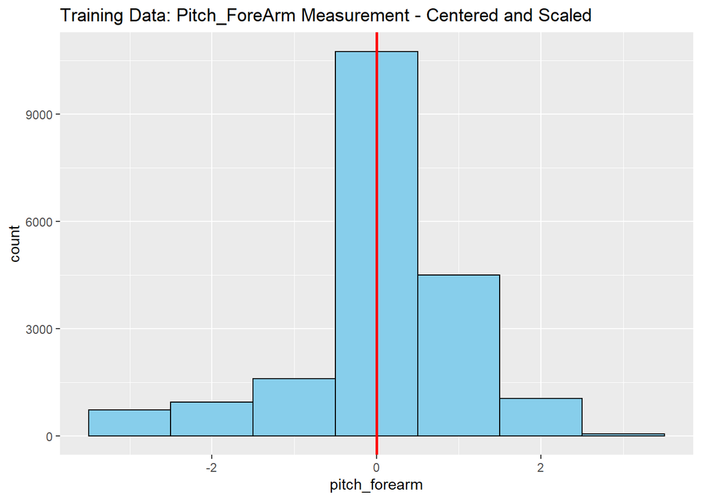

```r
res<-as.data.frame(scale(training[,meas],center=TRUE,scale=TRUE))
training<-res %>% mutate(classe=as.factor(training$classe)) #scaled/centered dataset
histplot<-ggplot(training,aes(x=pitch_forearm))+geom_histogram(color="black",fill="skyblue",linetype=1,size=0.5,binwidth=1) +geom_vline(xintercept=0,color="red",linetype=1,size=1)+labs(title="Training Data: Pitch_ForeArm Measurement - Centered and Scaled")
print(histplot)
```

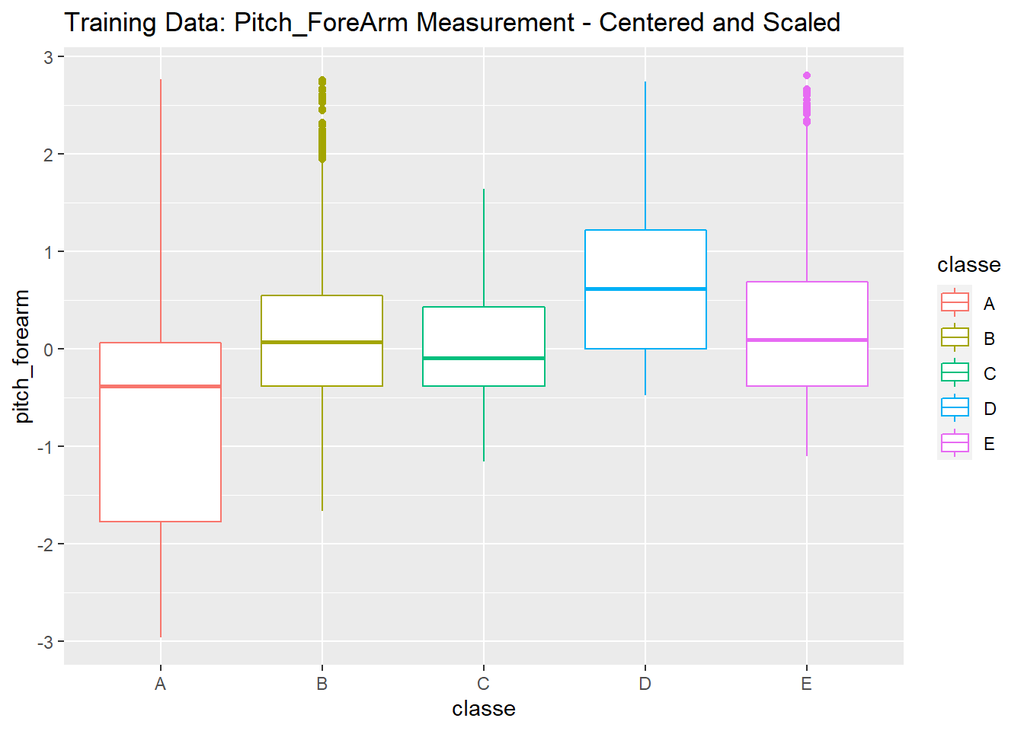

```r
print(ggplot(training,aes(classe,pitch_forearm)) + geom_boxplot(aes(color=classe))+labs(title="Training Data: Pitch_ForeArm Measurement - Centered and Scaled"))
```

## Data Partitioning

Since there are 19622, this data set can be partitioned into a train set and a verify set. The proportion of 80% train and 20% verify is used.

```r
set.seed(12345)
partdata<-createDataPartition(y=training$classe,p=.8,list=FALSE)
train<-training[partdata,];verif<-training[-partdata,]
obsTrainPart<-length(train);obsVerifyPart<-length(verif);
```

```r
kable(table(train$classe),col.names = c("Classe","Row Count"),caption="Train Partition","html") %>% kable_styling(full_width = F,font_size=11,position = "center")
```

Train Partition

| Classe | Row Count |
| --- | --- |
| A | 4464 |
| B | 3038 |
| C | 2738 |
| D | 2573 |
| E | 2886 |

In the verify data partition, the **Classe** values are distributed as:

```r
kable(table(verif$classe),col.names = c("Classe","Row Count"),caption="Verify Partition","html") %>% kable_styling(full_width = F,font_size=11,position = "center")
```

Verify Partition

| Classe | Row Count |
| --- | --- |
| A | 1116 |
| B | 759 |
| C | 684 |
| D | 643 |
| E | 721 |

## Model Development

Since the response variable for this project is a character-factor, the random forest classification model will be used for the initial model development. Depending the results of the predictions, another model may be evaluate if necessary.

```r
#Start Cluster
cluster <- makeCluster(detectCores() - 2) # left 2 cores available
registerDoParallel(cluster)

# Fit RF model with Cross validation resampling 5,7,10
set.seed(2345)
modFit5<-train(classe~.,method="rf",data = train,trainctr=trainControl(method="cv",number=5,allowParallel=TRUE))
modFit7<-train(classe~.,method="rf",data = train,trainctr=trainControl(method="cv",number=7,allowParallel=TRUE))
modFit10<-train(classe~.,method="rf",data = train,trainctr=trainControl(method="cv",number=10,allowParallel=TRUE))

# Stop Processing Cluster
stopCluster(cluster)
registerDoSEQ()
```

### Random Forest Model Results

```r
res<-data.frame(model=c("RF 5 ","RF 7 ","RF 10 "),Max_accuracy=c(max(modFit5$results$Accuracy),max(modFit7$results$Accuracy),max(modFit10$results$Accuracy)),
                Max_kappa=c(max(modFit5$results$Kappa),max(modFit7$results$Kappa),max(modFit10$results$Kappa)),Mean_errate=c(mean(modFit5$finalModel$err.rate),mean(modFit7$finalModel$err.rate),mean(modFit10$finalModel$err.rate)))
kable(res,col.names = c("Model","Max Accuracy","Max Kappa","Mean Error Rate"),caption="RF Models - Train Data: 5, 7, and 10 Resampling Iterations","html") %>% kable_styling(full_width = F,font_size=11,position = "center")
```

| Model | Max Accuracy | Max Kappa | Mean Error Rate |
| --- | --- | --- | --- |
| RF 5 | 0.9840217 | 0.9797831 | 0.0127695 |
| RF 7 | 0.9843350 | 0.9801812 | 0.0130015 |
| RF 10 | 0.9839012 | 0.9796279 | 0.0152629 |

## Final Model

The final model results (RF 7) are shown below. The Model uses 500 trees with 10 randomly select variables for each split. The **estimated error rate** is 0.99%

```r
print(modFit7$finalModel)
```

```
##
## Call:
##  randomForest(x = x, y = y, mtry = param$mtry, trainctr = ..1)
##                Type of random forest: classification
##                      Number of trees: 500
## No. of variables tried at each split: 10
##
##         OOB estimate of  error rate: 0.99%
## Confusion matrix:
##      A    B    C    D    E class.error
## A 4451    5    5    1    2 0.002912186
## B   17 2988   19   10    4 0.016458196
## C    1   15 2706   14    2 0.011687363
## D    1    1   31 2539    1 0.013214147
## E    0   10    9    7 2860 0.009009009
```

### Results

The complete results the final model follow. Note the best results are for 10 variables sampled at each split (mtry = 10).

```r
#print(modFit7$results)
kable(modFit7$results,col.names = c("mtry","Accuracy","Kappa","Accuracy SD","Kappa SD"),caption="RF Model Final Results","html") %>% kable_styling(full_width = F,font_size=11,position = "center")
```

RF Model Final Results

| mtry | Accuracy | Kappa | Accuracy SD | Kappa SD |
| --- | --- | --- | --- | --- |
| 2 | 0.9840111 | 0.9797695 | 0.0015323 | 0.0019366 |
| 10 | 0.9843350 | 0.9801812 | 0.0015865 | 0.0020043 |
| 18 | 0.9750580 | 0.9684443 | 0.0028858 | 0.0036458 |

The accuracy of the model declines after 10 randomly selected predictors are used as shown in the graph below:

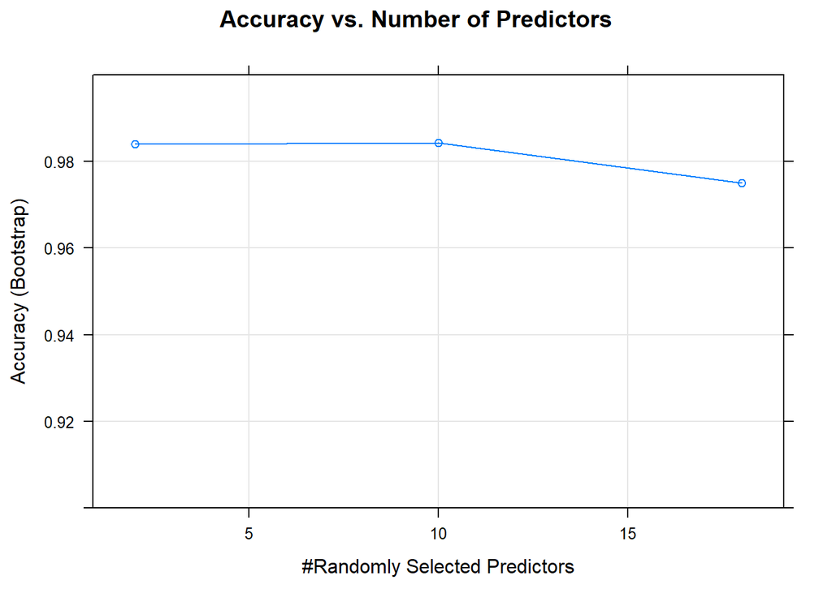

```r
plot(modFit7, ylim=c(0.9,1),main="Accuracy vs. Number of Predictors")
```

### Variable Importance

The top ten predictors listed by Overall importance in the model are:

```r
vars<-arrange(round(varImp(modFit7)$importance,2),-Overall)
#print(top_n(vars,n=10))
kable(top_n(vars,n=10),col.names = c("Importance"),caption="RF Model: Top 10 Vars Overall Importance","html") %>% kable_styling(full_width = F,font_size=11,position = "center")
```

RF Model: Top 10 Vars Overall Importance

|  | Importance |
| --- | --- |
| roll_belt | 100.00 |
| pitch_belt | 46.44 |
| pitch_forearm | 43.77 |
| roll_forearm | 33.83 |
| magnet_dumbbell_x | 30.44 |
| roll_dumbbell | 20.74 |
| magnet_forearm_z | 13.34 |
| yaw_dumbbell | 10.72 |
| roll_arm | 9.06 |
| magnet_forearm_x | 5.50 |

## Testing the Model with Verify Data

The verify data was used to test the model by predicting the Classe and comparing the predictions to the Classe variable in the data. The overall results are shown below. Note that both the Accuracy and Kappa values for the predictions are high at 0.99 (rounded values).

```r
## Prediction with Verify data set
predictions<- predict(modFit7,newdata=verif)
cmx<-confusionMatrix(predictions,verif$classe)
print(cmx$overall)
```

```
##       Accuracy          Kappa  AccuracyLower  AccuracyUpper   AccuracyNull
##      0.9918430      0.9896805      0.9885041      0.9944141      0.2844762
## AccuracyPValue  McnemarPValue
##      0.0000000            NaN
```

### Predicted Classes from Model

The detailed prediction results for the verify data are shown below. Note that predictions for Classe = A and Classe = E show the least number of incorrect classifications (less than 1%).

```r
verif$predRight <- predictions==verif$classe
respreds<-table(predictions,verif$classe)
print(respreds)
```

```
##
## predictions    A    B    C    D    E
##           A 1116    3    1    0    0
##           B    0  754    5    1    1
##           C    0    2  676   14    1
##           D    0    0    2  627    1
##           E    0    0    0    1  718
```